# Biodistribution

# Create graphs for fig1

We will group by tissue type and split each tissue by time point. Each individual observation is plotted as a dot, with the mean plotted as a bar and the standard error plotted for the error bar.

```
## No summary function supplied, defaulting to `mean_se()`
## No summary function supplied, defaulting to `mean_se()`
```

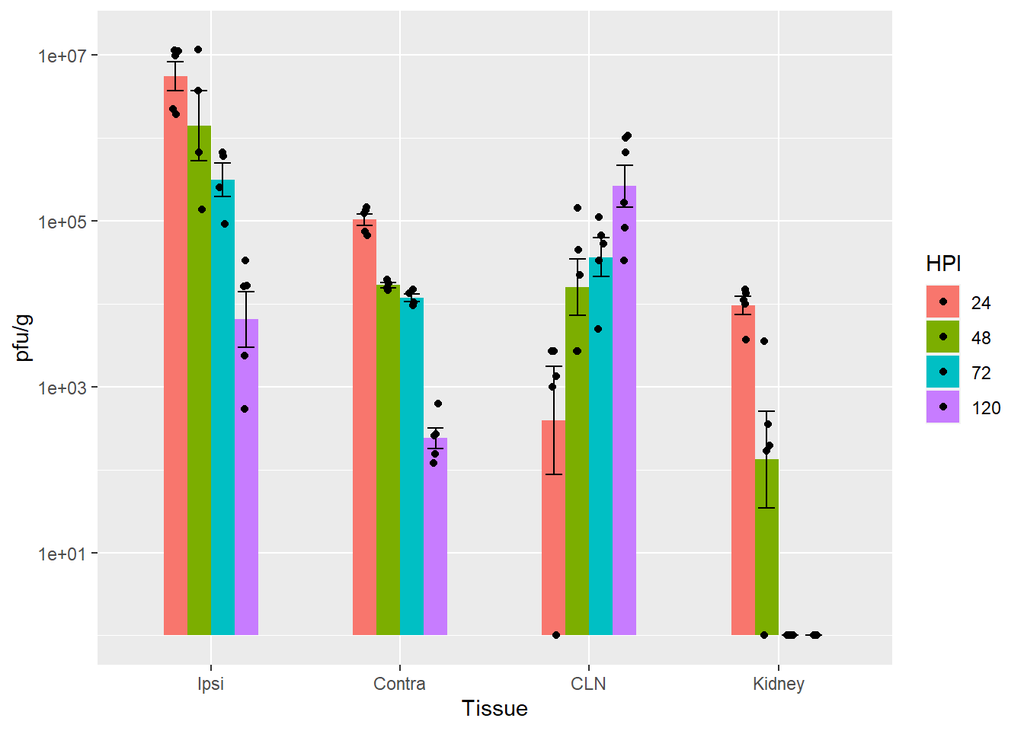

```
## No summary function supplied, defaulting to `mean_se()`
## No summary function supplied, defaulting to `mean_se()`
```

# Figure 2 - Toggle experiment August

We will perform a similar analysis for the August time point which is focused on the receptor toggling. We will compare each tissue type by transgenic and non-transgenic mice, so we will create a data set consisting of the August observation point that does include both transgenic and non-transgenic mice.

```
## # A tibble: 6 x 6
##   mouse ltr   intrvl obs_pt    tissue pfu_g
##   <chr> <chr>  <dbl> <chr>     <fct>  <dbl>
## 1 Ntg   A        120 august_22 Ipsi    1874
## 2 Ntg   A        120 august_22 Contra   890
## 3 Ntg   A        120 august_22 CLN        1
## 4 Ntg   B        120 august_22 Ipsi    1482
## 5 Ntg   B        120 august_22 Contra   834
## 6 Ntg   B        120 august_22 CLN        1
```

We will graph the August data the same as the July data.

```
## starting httpd help server ... done
## No summary function supplied, defaulting to `mean_se()`
## No summary function supplied, defaulting to `mean_se()`
```

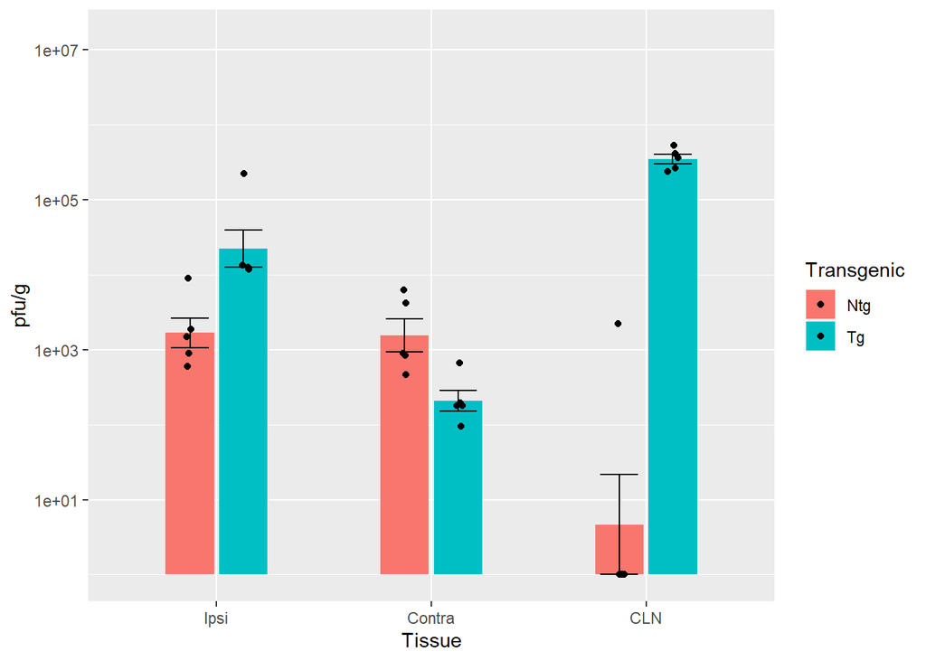

```
## No summary function supplied, defaulting to `mean_se()`
## No summary function supplied, defaulting to `mean_se()`
```